# Assessment of human DMG DE miRNA ortholog expression in B7H3 treated mice

Ryan Corbett

2026

This script identifies mouse orthologs of human DE miRNAs in DMG versus normal brain by cluster, and assesses their expression patterns in B7H3 treated mice

Load packages

```r
suppressPackageStartupMessages({
  library(rprojroot)
  library(tidyverse)
  library(ggplot2)
  library(gtools)
  library(ggsci)
  library(ggpubr)
})
```

Set dir paths

```r
root_dir <- rprojroot::find_root(rprojroot::has_dir(".git"))
data_dir <- file.path(root_dir, "data")
analysis_dir <- file.path(root_dir, "analyses", "human-mirna-expr-in-mouse")
results_dir <- file.path(analysis_dir, "results")
plot_dir <- file.path(analysis_dir, "plots")

# source plotting theme
source(file.path(root_dir, "figures", "theme.R"))
```

Set file paths

```r
# human DMG clustering file
dmg_cluster_file <- file.path(root_dir, "analyses",
                              "mirna-clustering",
                              "results",
                              "DIPG or DMG-de-mirna-cluster-membership-immune-scores.tsv")

# mouse miRNA counts file
mmu_mirna_ct_file <- file.path(data_dir,
                               "30-963755216-miRNA_expression.csv")

# mouse differential expression results
mmu_de_file <- file.path(root_dir, "analyses",
                         "murine-mirna-differential-expression",
                         "results",
                         "mirna-differential-expression-deseq2-b7h3-stop-vs-untreated-by-timepoint.tsv")
```

Wrangle data, and remove species prefix from miRNA IDs to match orthologs

```r
# Load hsa DMG miRNA cluster df and filter for cluster 6 miRNAs
dmg_hsa_mir_df <- read_tsv(dmg_cluster_file) %>%
  dplyr::filter(grepl("hsa", miRNA)) %>%
  dplyr::mutate(miRNA = str_remove(miRNA, "hsa-"))
# Load mouse miRNA expression file and determine number of cluster 6 miRNAs with ortholog
mmu_mirna_ct_df <- read_csv(mmu_mirna_ct_file) %>%
  dplyr::rename("mirna_id" = "...1") %>%
  dplyr::mutate(mirna_id = str_remove(mirna_id, "mmu-"))
```

```
## ───────────────────────────────────────────────────────────────────────────────────────────────────────────────────────────────────── Delimiter: "," chr
## (1): ...1 dbl (22): Day14-Tube1, Day14-Tube2, RESUB-Day14-Tube3, Day14-Tube4, Day14-Tu...
```

```r
# Load merged mouse differential expression results
mmu_de_df <- read_tsv(mmu_de_file) %>%
  dplyr::mutate(mirna_id = str_remove(mirna_id, "mmu-"))
```

Extract DE miRNA groups in mouse data: 1) All DE miRs 2) upregulated D14 3) downregulated D14 4) upregulated D21 5) downregulated D21

```r
all_de_mirs <- mmu_de_df %>%
  dplyr::filter(status_Day14 != "Not DE" | status_Day21 != "Not DE") %>%
  pull(mirna_id)

d14_up_mirs <- mmu_de_df %>%
  dplyr::filter(status_Day14 == "B7H3 upregulated") %>%
  pull(mirna_id)

d14_down_mirs <- mmu_de_df %>%
  dplyr::filter(status_Day14 == "B7H3 downregulated") %>%
  pull(mirna_id)

d21_up_mirs <- mmu_de_df %>%
  dplyr::filter(status_Day21 == "B7H3 upregulated") %>%
  pull(mirna_id)

d21_down_mirs <- mmu_de_df %>%
  dplyr::filter(status_Day21 == "B7H3 downregulated") %>%
  pull(mirna_id)
```

Create list of DE miRNA groups

```r
de_mir_list <- list("All DE" = all_de_mirs,
                    "D14 Up" = d14_up_mirs,
                    "D14 Down" = d14_down_mirs,
                    "D21 Up" = d21_up_mirs,
                    "D21 Down" = d21_down_mirs)
```

Create data frame to store orthology and expression results by miRNA cluster

```r
cluster_summary_df <- tibble(
                             # repeat miR clusters to test for enrichment within each mouse DE group
                             hsa_dmg_cluster = rep(unique(dmg_hsa_mir_df$row_cluster), each = 5),
                             de_mir_group = rep(names(de_mir_list), 8),
                             total_n = NA_integer_,
                             n_mmu_orthologs = NA_integer_,
                             n_expr_orthologs = NA_integer_,
                             n_expr_group = NA_integer_,
                             n_mmu_mir = sum(!grepl("Novel", mmu_de_df$mirna_id)),
                             OR = NA_integer_,
                             OR_p = NA_integer_,
                             OR_CI_lower = NA_integer_,
                             OR_CI_upper = NA_integer_)
```

Loop through rows of `cluster_summary_df` to 1) identify number of total and expressed mouse orthologs per human DMG miR cluster 2) Assess enrichment of orthologs for miRNAs of different B7H3-associated expression patterns

```r
for (i in 1:nrow(cluster_summary_df)){

  # get cluster
  clust <- cluster_summary_df$hsa_dmg_cluster[i]

  # get miRNAs in cluster
  cluster_mirs <- dmg_hsa_mir_df %>%
    dplyr::filter(row_cluster == clust) %>%
    # remove hsa prefix from miRNA ID
    dplyr::mutate(miRNA = str_remove(miRNA, "hsa-")) %>%
    pull(miRNA)

  # after removing species prefix, orthologous miRNAs will share the same name between species
  # determine how many hsa DMG cluster miRNAs have orthologs in mice:
  cluster_mirs_w_ortholog <- mmu_mirna_ct_df %>%
    dplyr::filter(mirna_id %in% cluster_mirs) %>%
    pull(mirna_id)

  # get N expressed orthologs from DE df
  expr_orthologs <- mmu_de_df %>%
    dplyr::filter(mirna_id %in% cluster_mirs) %>%
    pull(mirna_id)

  # append stats to summary df
  cluster_summary_df$total_n[i] <- length(cluster_mirs)
  cluster_summary_df$n_mmu_orthologs[i] <- length(cluster_mirs_w_ortholog)
  cluster_summary_df$n_expr_orthologs[i] <- length(expr_orthologs)

  # define current DE group and miRs in group
  de_group <- cluster_summary_df$de_mir_group[i]

  de_mirs <- de_mir_list[[de_group]]

  # determine number of orthologs in cluster and expression group
  n_ortho_de <- length(intersect(expr_orthologs,
                                 de_mirs))

  cluster_summary_df$n_expr_group[i] <- n_ortho_de

  # run fisher's exact test to assess for enrichment of orthologs in DE group
  ftest <- fisher.test(matrix(c(n_ortho_de,
                                length(expr_orthologs) - n_ortho_de,
                                length(de_mirs) - n_ortho_de,
                                cluster_summary_df$n_mmu_mir[i] - n_ortho_de - (length(expr_orthologs) - n_ortho_de) - (length(de_mirs) - n_ortho_de)),
                              nrow = 2))

  # append FET stats to summary df
  cluster_summary_df$OR[i] <- ftest$estimate
  cluster_summary_df$OR_p[i] <- ftest$p.value
  cluster_summary_df$OR_CI_lower[i] <- ftest$conf.int[1]
  cluster_summary_df$OR_CI_upper[i] <- ftest$conf.int[2]

}
```

Generate df to plot % orthologs identified by cluster

```r
ortho_plot_df <- cluster_summary_df %>%
  # retain one row per cluster
  distinct(hsa_dmg_cluster, .keep_all = TRUE) %>%
  dplyr::select(hsa_dmg_cluster,
                total_n,
                n_mmu_orthologs,
                n_expr_orthologs) %>%
  dplyr::rename(`Expressed ortholog` = n_expr_orthologs) %>%
  dplyr::mutate(`Non-expressed ortholog` = n_mmu_orthologs - `Expressed ortholog`,
                `No ortholog` = total_n - n_mmu_orthologs) %>%
  dplyr::select(-n_mmu_orthologs, -total_n) %>%
  pivot_longer(-hsa_dmg_cluster,
               names_to = "category",
               values_to = "n") %>%
  dplyr::mutate(category = fct_relevel(category,
                                       c("Expressed ortholog",
                                         "Non-expressed ortholog",
                                         "No ortholog"))) %>%
  dplyr::mutate(hsa_dmg_cluster = as.factor(hsa_dmg_cluster)) %>%
  dplyr::mutate(hsa_dmg_cluster = fct_relevel(hsa_dmg_cluster,
                                              rev(unique(as.character(hsa_dmg_cluster)))))
```

Plot percent orthologs identified per cluster

```r
ortho_plot <- ggplot(ortho_plot_df,
                      aes(x = n,
                          y = hsa_dmg_cluster,
                          fill = category)) +
  geom_bar(stat = "identity",
           color = "black") +
  labs(x = "n miRNAs",
       y = "human DMG DE\nmiRNA cluster") +
  scale_fill_npg() +
  theme_Publication() +
  theme(
    legend.position = "top"
  )

ggsave(file.path(plot_dir, "hsa-dmg-de-mirna-mmu-ortho-barplot.pdf"),
       ortho_plot,
       width = 3.5, height = 4.5)
```

Reorder expr group levels and create columns `perc_text`, `p_text` to show fractions in plots

```r
cluster_summary_df <- cluster_summary_df %>%
  dplyr::mutate(de_mir_group = fct_relevel(de_mir_group,
                                           c("D21 Down",
                                             "D21 Up",
                                             "D14 Down",
                                             "D14 Up",
                                             "All DE"))) %>%
  dplyr::mutate(perc_text = glue::glue("{n_expr_group}/{n_expr_orthologs}")) %>%
  dplyr::mutate(p_text = case_when(
    OR_p < 0.01 ~ "**",
    OR_p < 0.05 ~ "*",
    TRUE ~ ""
  ))
```

Plot enrichment of miRNAs in B7H3-associated expression groups in mouse by cluster

```r
enr_plot <- cluster_summary_df %>%
  # remove clusters with <2 orthologous miRNAs
  dplyr::filter(!hsa_dmg_cluster %in% c(2,7)) %>%
  dplyr::mutate(OR = case_when(
    is.infinite(OR) ~ 1000,
    TRUE ~ OR
  )) %>%
  dplyr::mutate(OR_CI_upper = case_when(
    is.infinite(OR_CI_upper) ~ 100,
    TRUE ~ OR_CI_upper
  )) %>%
  ggplot(aes(x = log10(OR), y = factor(de_mir_group),
             color = factor(de_mir_group),
             label = p_text)) +
  geom_point(size = 3, show.legend = FALSE) +
  # add log10-transformed confidence intervals
  geom_errorbar(aes(xmin = log10(OR_CI_lower), xmax = log10(OR_CI_upper),
                    color = factor(de_mir_group)), width = 0.2,
                show.legend = FALSE) +
  geom_text(x = 1.5, hjust = 0, size = 6, fontface = 2,
            show.legend = FALSE) +
  labs(x = "log10-Odds Ratio\n(95% CI)", y = "B7H3 DE miRNA class") +
  # Add OR threshold line
  geom_vline(xintercept = 0, linetype = "dashed") +
  # facet wrap by variable, place strips to left
  facet_wrap(~hsa_dmg_cluster, scale = "fixed",
             nrow = 8,
             strip.position = "left") +
  expand_limits(y=0) +
  scale_color_manual(values = c("#3C5488FF", "#E64B35FF",
                                "#4DBBD5FF", "#F39B7FFF",
                                "#00A087FF")) +
  theme_Publication()
```

Plot percent of expressed orthologs in B7H3-associated expression groups by cluster

```r
perc_plot <- cluster_summary_df %>%
  dplyr::filter(!hsa_dmg_cluster %in% c(2,7)) %>%
  ggplot(aes(x = n_expr_group/n_expr_orthologs * 100,
             y = factor(de_mir_group),
             fill = factor(de_mir_group),
             color = factor(de_mir_group),
             label = perc_text)) +
  geom_bar(stat = "identity", color = "black",
           show.legend = FALSE) +
  # add fractions to the right of plots
  geom_text(x = 60, hjust = 0, size = 4, fontface = 2,
            show.legend = FALSE) +
  labs(x = "% human orthologs\n", y = NULL, fill = NULL) +
  scale_y_discrete(labels=c("PBTA" = NULL, "gnomAD" = NULL,
                            "PMBB" = NULL)) +
  guides(fill = guide_legend(nrow = 1)) +
  # facet wrap by variable, place strip to left of plot
  facet_wrap(~hsa_dmg_cluster, scale = "fixed",
             nrow = 6,
             strip.position = "left") +
  coord_cartesian(clip = 'off') +
  xlim(c(0, 55)) +
  scale_fill_manual(values = c("#3C5488FF", "#E64B35FF",
                                "#4DBBD5FF", "#F39B7FFF",
                                "#00A087FF")) +
  scale_color_manual(values = c("#3C5488FF", "#E64B35FF",
                                "#4DBBD5FF", "#F39B7FFF",
                                "#00A087FF")) +
  theme_Publication() +
  # remove facet strips
  theme(plot.margin = unit(c(2,5,1,1), "lines"),
        legend.position.inside = c(0.5, 1.07),
        strip.background = element_blank(),
        strip.text.y = element_blank()) +
  theme(strip.placement = "outside")
```

Merge enrichment and percent plots and save

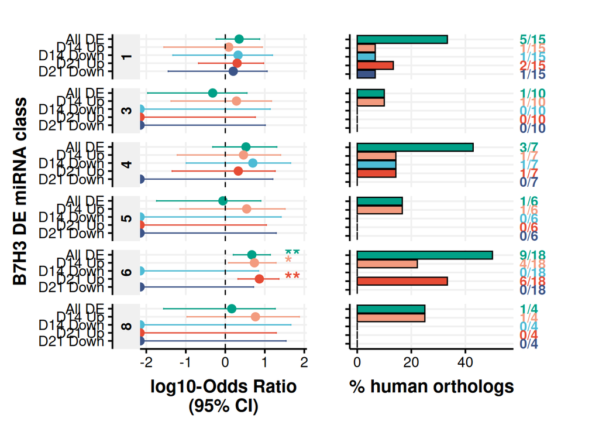

```r
merged_plot <- ggarrange(enr_plot, perc_plot,
                         nrow = 1, widths = c(1,0.85),
                         align = "h")

merged_plot
```

```r
pdf(file.path(plot_dir,
                 "human-dmg-de-mirna-orthology-mouse-expr-enrichment-plot.pdf"),
       width = 6, height = 8)

merged_plot

dev.off()
```